# URL Phishing :

## 11. Distribution of first directory length

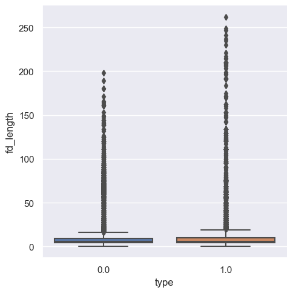

```python
sns.set(style="darkgrid")
ax = sns.catplot(x="type", y="fd_length", kind="box", data=df)
```

## 12. Distribution of top-level domain length

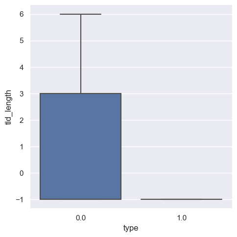

```python
sns.set(style="darkgrid")
ax = sns.catplot(x="type", y="tld_length", kind="box", data=df)
```

```python
# les top level domain sont significative pour les safe URL
```

## Target Encoding

```python
from sklearn.preprocessing import LabelEncoder

lb_make = LabelEncoder()
df["type_code"] = lb_make.fit_transform(df["type"])
df["type_code"].value_counts()
```

```
0    92680
1    28310
Name: type_code, dtype: int64
```

## Creation of Feature & Target

```python
# ici je vais trié les variables les plus importantes a partir des visuelles
# la variable de google est pas significative donc je vais la drop
#
```

```python
#Predictor Variables
# filtering out google_index as it has only 1 value
X = df[['use_of_ip','abnormal_url', 'count.', 'count-www', 'count@',
       'count_dir', 'count_embed_domian', 'short_url', 'count-https',
       'count-http', 'count%', 'count?', 'count-', 'count=', 'url_length',
       'hostname_length', 'sus_url', 'fd_length', 'tld_length', 'count-digits',
       'count-letters']]

#Target Variable
y = df['type_code']
```

```python
X.head()
```

|  | use_of_ip | abnormal_url | count. | count-www | count@ | count_dir | count_embed_domian | short_url | count-https | count-http | ... | count? | count- | count= | url_length | hostname_length | sus_url | fd_length | tld_length | count-digits | count-letters |
| --- | --- | --- | --- | --- | --- | --- | --- | --- | --- | --- | --- | --- | --- | --- | --- | --- | --- | --- | --- | --- | --- |
| 0 | 0 | 1 | 2 | 0 | 0 | 4 | 0 | 1 | 0 | 1 | ... | 1 | 0 | 1 | 105 | 10 | 0 | 8 | 3 | 0 | 89 |
| 1 | 0 | 0 | 3 | 0 | 0 | 3 | 0 | 0 | 0 | 0 | ... | 0 | 0 | 0 | 37 | 0 | 0 | 8 | -1 | 0 | 30 |
| 2 | 0 | 1 | 1 | 0 | 0 | 4 | 0 | 0 | 0 | 1 | ... | 0 | 10 | 0 | 131 | 6 | 0 | 8 | 2 | 8 | 105 |
| 3 | 0 | 0 | 2 | 1 | 0 | 6 | 0 | 0 | 0 | 0 | ... | 0 | 0 | 0 | 52 | 0 | 0 | 7 | -1 | 11 | 33 |
| 4 | 0 | 0 | 3 | 0 | 0 | 3 | 0 | 1 | 0 | 0 | ... | 0 | 1 | 0 | 48 | 0 | 0 | 11 | -1 | 0 | 40 |

5 rows × 21 columns

Mon prétraitement des données s'arrête ici. J'ai pris les 21 colonnes, bien que j'aurais pu enlever encore davantage de variables telles que l'adresse IP, etc. Je choisis de travailler avec ce jeu de données pour le moment afin de voir les résultats de l'entraînement. Si les résultats ne sont pas satisfaisants, je pourrais envisager un autre traitement pour retirer davantage de variables.

Si le temps ne posait pas de contrainte dans ce contexte, j'aurais essayé plusieurs combinaisons de jeux de données. Cependant, compte tenu des impératifs temporels, il est nécessaire de faire un choix. Le choix actuel me semble optimal.

```python
X.columns
```

```
Index(['use_of_ip', 'abnormal_url', 'count.', 'count-www', 'count@',
       'count_dir', 'count_embed_domian', 'short_url', 'count-https',
       'count-http', 'count%', 'count?', 'count-', 'count=', 'url_length',
       'hostname_length', 'sus_url', 'fd_length', 'tld_length', 'count-digits',
       'count-letters'],
      dtype='object')
```

## Train Test Split

```python
X_train, X_test, y_train, y_test = train_test_split(X, y, stratify=y, test_size=0.2,shuffle=True, random_state=5)
```

```python
# 80 % pour l'entrainement et 20 % pour le test
# stratify=y pour avoir des proportions equilibrées
```

# 3-Model Building

## 1. Random Forest Classifier - modele de base

```python
from sklearn.ensemble import RandomForestClassifier
from sklearn import metrics

rf = RandomForestClassifier(n_estimators=100,max_features='sqrt')
rf.fit(X_train,y_train)
y_pred_rf = rf.predict(X_test)
print(classification_report(y_test,y_pred_rf,target_names=['0.0', '1.0']))

score = metrics.accuracy_score(y_test, y_pred_rf)
print("accuracy:   %0.3f" % score)
```

```
              precision    recall  f1-score   support

         0.0       0.96      0.97      0.97     18536
         1.0       0.90      0.88      0.89      5662

    accuracy                           0.95     24198
   macro avg       0.93      0.92      0.93     24198
weighted avg       0.95      0.95      0.95     24198

accuracy:   0.948
```

**Précision :**

Pour la classe "0.0", la précision est de 96%. Cela signifie que parmi toutes les instances prédites comme appartenant à la classe "0.0", 96% d'entre elles sont effectivement de cette classe. Pour la classe "1.0", la précision est de 90%. Cela signifie que parmi toutes les instances prédites comme appartenant à la classe "1.0", 90% d'entre elles sont effectivement de cette classe.

**Rappel (Recall) :**

Pour la classe "0.0", le rappel est de 97%. Cela signifie que parmi toutes les instances réellement de la classe "0.0", le modèle en a correctement identifié 97%. Pour la classe "1.0", le rappel est de 88%. Cela signifie que parmi toutes les instances réellement de la classe "1.0", le modèle en a correctement identifié 88%.

**F1-score :**

Le F1-score est une mesure qui combine à la fois la précision et le rappel en une seule métrique. Il est calculé comme la moyenne harmonique de la précision et du rappel. Un F1-score élevé indique un bon équilibre entre la précision et le rappel. Pour la classe "0.0", le F1-score est de 0.97. Pour la classe "1.0", le F1-score est de 0.89.

Support :

**Accuracy :**

L'exactitude globale est de 0.948, ce qui indique que le modèle prédit correctement la classe pour 94.8% de toutes les instances dans l'ensemble de données de test. En résumé, ces résultats montrent que le modèle a de bonnes performances globales, avec une précision élevée et un bon équilibre entre la précision et le rappel pour les deux classes. Cependant, le rappel pour la classe "1.0" est légèrement plus bas que pour la classe "0.0", ce qui signifie que le modèle peut avoir plus de difficulté à identifier correctement les instances de la classe "1.0", **ptet c'est du a taille des classes 0 beacoup plus importante que la classe 1**

[figure not shown]

```python
cm = confusion_matrix(y_test, y_pred_rf)
cm_df = pd.DataFrame(cm,
                     index = ['0.0', '1.0'],
                     columns = ['1.0', '1.0'])
plt.figure(figsize=(8,6))
sns.heatmap(cm_df, annot=True,fmt=".1f")
plt.title('Confusion Matrix')
plt.ylabel('Actal Values')
plt.xlabel('Predicted Values')
plt.show()
```

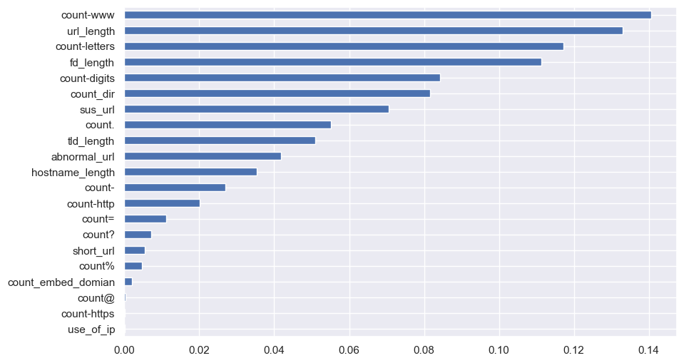

```python
## la proportion de ^rediction des label 1 est faible par rapport au label 0, cela revient a taille de base de donnée des 1

feat_importances = pd.Series(rf.feature_importances_, index=X_train.columns)
feat_importances.sort_values().plot(kind="barh",figsize=(10, 6))
```

## 2. Light GBM Classifier

```python
lgb = LGBMClassifier(objective='binary',boosting_type= 'gbdt',n_jobs = 5,
          verbosity=-1, random_state=5)
LGB_C = lgb.fit(X_train, y_train)


y_pred_lgb = LGB_C.predict(X_test)
print(classification_report(y_test,y_pred_lgb,target_names=['0.0', '1.0']))

score = metrics.accuracy_score(y_test, y_pred_lgb)
print("accuracy:   %0.3f" % score)
```

```
              precision    recall  f1-score   support

         0.0       0.96      0.97      0.97     18536
         1.0       0.91      0.86      0.88      5662

    accuracy                           0.95     24198
   macro avg       0.93      0.92      0.93     24198
weighted avg       0.95      0.95      0.95     24198

accuracy:   0.948
```

ces résultats montrent que le modèle de boosting a de bonnes performances globales, avec une précision élevée pour les deux classes. Cependant, le rappel pour la classe "1.0" est légèrement plus bas que pour la classe "0.0", ce qui signifie que le modèle a plus de difficulté à identifier correctement les instances de la classe "1.0" par rapport à la classe "0.0"

**Comparaison entre les deux modeles (randonforest et boost)**

En comparant ces deux ensembles de résultats,nous pouvons voir que les performances des deux modèles sont assez similaires. Les deux modèles ont des précisions élevées pour les deux classes, ainsi que des rappels élevés pour la classe "0.0".

Cependant, le modèle de random forest semble avoir un meilleur rappel pour la classe "1.0" par rapport au modèle de boosting.

Il peut être judicieux de comparer ces modèles sur différentes métriques et d'utiliser des techniques de validation croisée pour choisir celui qui convient le mieux à la problematique

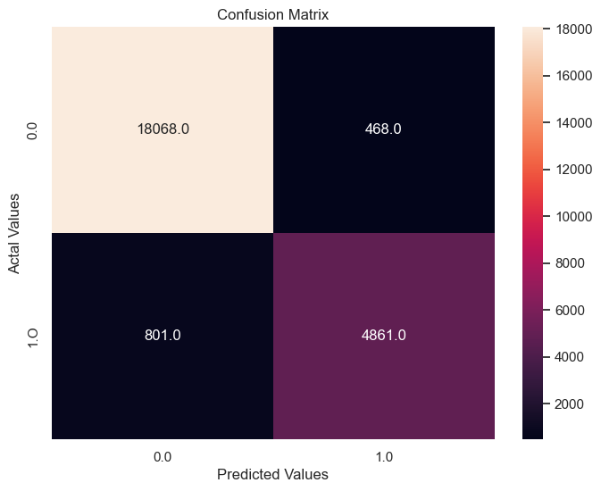

```python
cm = confusion_matrix(y_test, y_pred_lgb)
cm_df = pd.DataFrame(cm,
                     index = ['0.0', '1.O'],
                     columns = ['0.0', '1.0'])
plt.figure(figsize=(8,6))
sns.heatmap(cm_df, annot=True,fmt=".1f")
plt.title('Confusion Matrix')
plt.ylabel('Actal Values')
plt.xlabel('Predicted Values')
plt.show()
```

Vrai négatifs (True Negatives, TN) : Il y a 18068 observations qui appartiennent réellement à la classe "0.0" (classe négative) et qui ont été correctement prédites comme appartenant à la classe "0.0" par le modèle.

Faux positifs (False Positives, FP) : Il y a 468 observations qui appartiennent réellement à la classe "0.0", mais qui ont été incorrectement prédites comme appartenant à la classe "1.0" (classe positive) par le modèle.

Faux négatifs (False Negatives, FN) : Il y a 801 observations qui appartiennent réellement à la classe "1.0", mais qui ont été incorrectement prédites comme appartenant à la classe "0.0" par le modèle.

Vrai positifs (True Positives, TP) : Il y a 4861 observations qui appartiennent réellement à la classe "1.0" et qui ont été correctement prédites comme appartenant à la classe "1.0" par le modèle

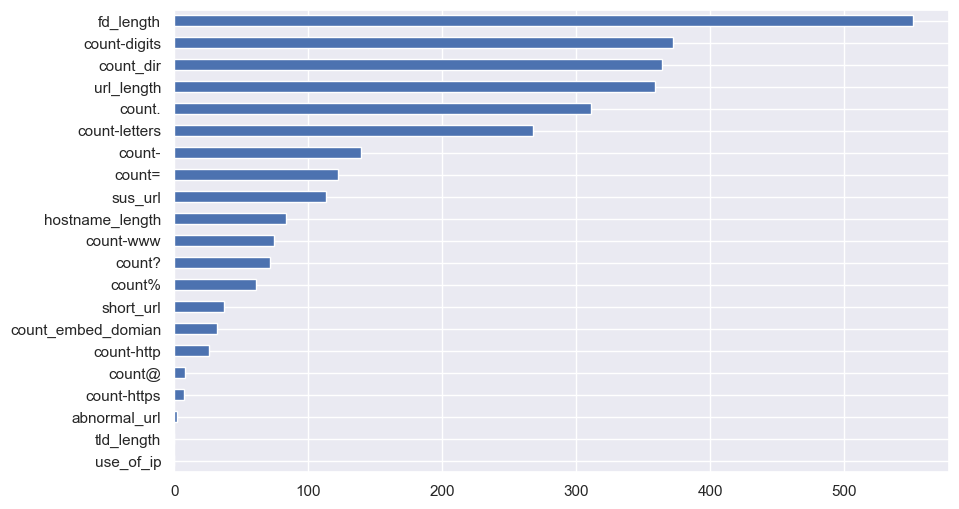

```python
feat_importances = pd.Series(lgb.feature_importances_, index=X_train.columns)
feat_importances.sort_values().plot(kind="barh",figsize=(10, 6))
```

## 3. XGboost Classifier

```python
xgb_c = xgb.XGBClassifier(n_estimators= 100)
xgb_c.fit(X_train,y_train)
y_pred_x = xgb_c.predict(X_test)
print(classification_report(y_test,y_pred_x,target_names=['0.0', '0.1']))

score = metrics.accuracy_score(y_test, y_pred_x)
print("accuracy:   %0.3f" % score)
```

```
              precision    recall  f1-score   support

         0.0       0.96      0.98      0.97     18536
         0.1       0.91      0.86      0.89      5662

    accuracy                           0.95     24198
   macro avg       0.94      0.92      0.93     24198
weighted avg       0.95      0.95      0.95     24198

accuracy:   0.948
```

Il est normal que les résultats du modèle XGBoost Classifier soient similaires à ceux des modèles Random Forest et LightGBM si les données, la configuration du modèle et les hyperparamètres sont similaires. XGBoost est également un algorithme de boosting qui utilise des arbres de décision comme base.

Cependant, il est important de noter que même si les résultats globaux (précision, rappel, F1-score et exactitude) peuvent être similaires entre les modèles, les performances individuelles peuvent varier légèrement en fonction de la façon dont chaque algorithme gère les données et apprend les modèles. Certaines différences dans les performances des modèles peuvent être dues à des facteurs tels que la sensibilité aux données déséquilibrées, la sensibilité aux valeurs aberrantes et la complexité du modèle. Si j'avais eu plus de temps, j'aurais exploré ces pistes davantage.

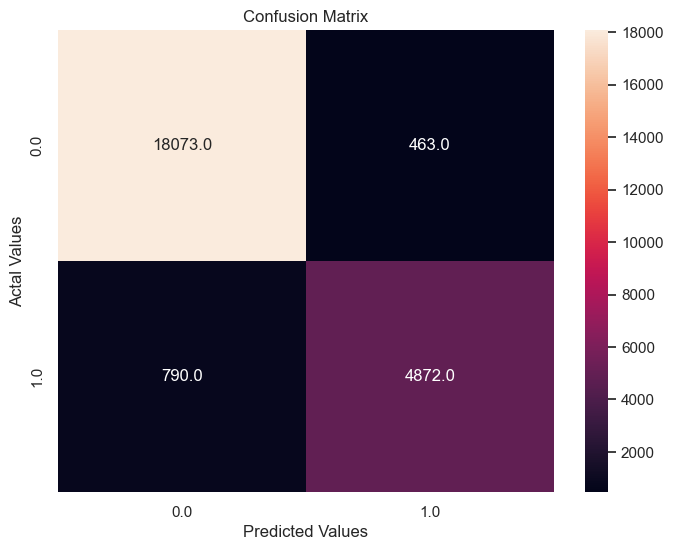

```python
cm = confusion_matrix(y_test, y_pred_x)
cm_df = pd.DataFrame(cm,
                     index = ['0.0', '1.0'],
                     columns = ['0.0', '1.0'])
plt.figure(figsize=(8,6))
sns.heatmap(cm_df, annot=True,fmt=".1f")
plt.title('Confusion Matrix')
plt.ylabel('Actal Values')
plt.xlabel('Predicted Values')
plt.show()
```

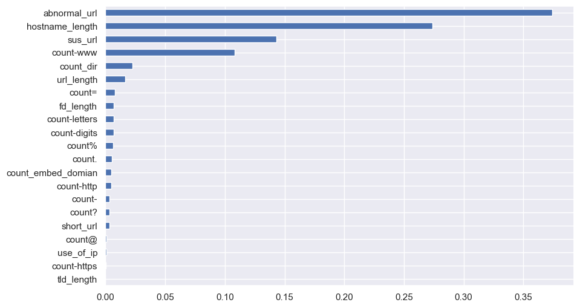

```python
feat_importances = pd.Series(xgb_c.feature_importances_, index=X_train.columns)
feat_importances.sort_values().plot(kind="barh",figsize=(10, 6))
```

### regression logistic

```python
from sklearn.linear_model import LogisticRegression
from sklearn.metrics import classification_report, accuracy_score
import numpy as np

# Initialiser le modèle de régression logistique
log_reg = LogisticRegression()

# Entraîner le modèle
log_reg.fit(X_train, y_train)

# Prédire les étiquettes sur l'ensemble de test
y_pred_log_reg = log_reg.predict(X_test)

# Afficher le rapport de classification
print(classification_report(y_test, y_pred_log_reg, target_names=['0.0', '0.1']))

# Calculer et afficher l'exactitude
accuracy = accuracy_score(y_test, y_pred_log_reg)
print("Accuracy: %.3f" % accuracy)
```

```
              precision    recall  f1-score   support

         0.0       0.90      0.95      0.93     18536
         0.1       0.81      0.66      0.73      5662

    accuracy                           0.88     24198
   macro avg       0.85      0.81      0.83     24198
weighted avg       0.88      0.88      0.88     24198

Accuracy: 0.884
```

```python
from sklearn.linear_model import LogisticRegression
from sklearn.metrics import classification_report, accuracy_score
from sklearn.preprocessing import StandardScaler

# Mettre à l'échelle les données
scaler = StandardScaler()
X_train_scaled = scaler.fit_transform(X_train)
X_test_scaled = scaler.transform(X_test)

# Initialiser le modèle de régression logistique avec un nombre d'itérations plus élevé
log_reg = LogisticRegression(max_iter=1000)

# Entraîner le modèle sur les données mises à l'échelle
log_reg.fit(X_train_scaled, y_train)

# Prédire les étiquettes sur l'ensemble de test
y_pred_log_reg = log_reg.predict(X_test_scaled)

# Afficher le rapport de classification
print(classification_report(y_test, y_pred_log_reg, target_names=['0.0', '0.1']))

# Calculer et afficher l'exactitude
accuracy = accuracy_score(y_test, y_pred_log_reg)
print("Accuracy: %.3f" % accuracy)
```

```
              precision    recall  f1-score   support

         0.0       0.90      0.95      0.93     18536
         0.1       0.82      0.66      0.73      5662

    accuracy                           0.89     24198
   macro avg       0.86      0.81      0.83     24198
weighted avg       0.88      0.89      0.88     24198

Accuracy: 0.885
```

## Prediction

```python
def main(url):

    status = []

    status.append(having_ip_address(url))
    status.append(abnormal_url(url))
    status.append(count_dot(url))
    status.append(count_www(url))
    status.append(count_atrate(url))
    status.append(no_of_dir(url))
    status.append(no_of_embed(url))

    status.append(shortening_service(url))
    status.append(count_https(url))
    status.append(count_http(url))

    status.append(count_per(url))
    status.append(count_ques(url))
    status.append(count_hyphen(url))
    status.append(count_equal(url))

    status.append(url_length(url))
    status.append(hostname_length(url))
    status.append(suspicious_words(url))
    status.append(digit_count(url))
    status.append(letter_count(url))
    status.append(fd_length(url))
    tld = get_tld(url,fail_silently=True)

    status.append(tld_length(tld))




    return status
```

```python
def get_prediction_from_url(test_url):
    features_test = main(test_url)
    # Due to updates to scikit-learn, we now need a 2D array as a parameter to the predict function.
    features_test = np.array(features_test).reshape((1, -1))



    pred = lgb.predict(features_test)
    if int(pred[0]) == 0:

        res="SAFE"
        return res
    elif int(pred[0]) == 1.0:

        res="PHISHING"
        return res
```

```python
urls = ['titaniumcorporate.co.za','en.wikipedia.org/wiki/North_Dakota']
for url in urls:
     print(get_prediction_from_url(url))
```

```
SAFE
PHISHING
```

## 4-optimisation

### Courbe de roc

```
[LightGBM] [Info] Number of positive: 22648, number of negative: 74144
[LightGBM] [Info] Auto-choosing row-wise multi-threading, the overhead of testing was 0.005755 seconds.
You can set `force_row_wise=true` to remove the overhead.
And if memory is not enough, you can set `force_col_wise=true`.
[LightGBM] [Info] Total Bins 1082
[LightGBM] [Info] Number of data points in the train set: 96792, number of used features: 20
[LightGBM] [Info] [binary:BoostFromScore]: pavg=0.233986 -> initscore=-1.185938
[LightGBM] [Info] Start training from score -1.185938
```

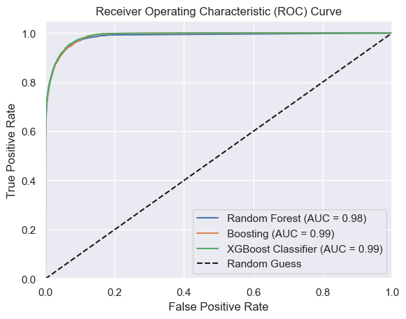

```python
import numpy as np
import matplotlib.pyplot as plt
from sklearn.metrics import roc_curve, auc
from sklearn.ensemble import RandomForestClassifier
from lightgbm import LGBMClassifier
from xgboost import XGBClassifier
from sklearn.model_selection import train_test_split
# Initialiser les trois modèles
models = {
    'Random Forest': RandomForestClassifier(),
    'Boosting': LGBMClassifier(objective='binary', boosting_type='gbdt', n_jobs=5, random_state=5),
    'XGBoost Classifier': XGBClassifier()
}

# Boucle sur les modèles
for name, model in models.items():
    model.fit(X_train, y_train)  # Formation du modèle
    y_score = model.predict_proba(X_test)[:, 1]  # Probabilités des classes positives

    # Calcul de la courbe ROC
    fpr, tpr, _ = roc_curve(y_test, y_score)
    roc_auc = auc(fpr, tpr)

    # Tracé de la courbe ROC
    plt.plot(fpr, tpr, label='{} (AUC = {:.2f})'.format(name, roc_auc))

# Tracé de la ligne en diagonale pour référence
plt.plot([0, 1], [0, 1], 'k--', label='Random Guess')

# Configuration du graphique
plt.xlim([0.0, 1.0])
plt.ylim([0.0, 1.05])
plt.xlabel('False Positive Rate')
plt.ylabel('True Positive Rate')
plt.title('Receiver Operating Characteristic (ROC) Curve')
plt.legend(loc='lower right')
plt.grid(True)

# Affichage du graphique
plt.show()
```

## 5-Stacking

Nous avons utilisé les prédictions des modèles de base (Random Forest, LightGBM, Régression Logistique) comme caractéristiques d'entraînement pour un modèle de régression logistique de méta-apprentissage. Ensuite, nous avons utilisé ce modèle de méta-apprentissage pour faire des prédictions finales sur l'ensemble de test et évalué ses performances à l'aide de la précision, du rappel, du F1-score et de l'exactitude.

j'ai ajouté le LGBMClassifier à côté du RandomForestClassifier et de la Régression Logistique comme modèle de base dans le stacking. Les prédictions de ces trois modèles sont ensuite utilisées comme caractéristiques d'entraînement pour un modèle de régression logistique de méta-apprentissage

```python
from sklearn.model_selection import train_test_split
from sklearn.ensemble import RandomForestClassifier
from lightgbm import LGBMClassifier
from sklearn.linear_model import LogisticRegression
from sklearn.metrics import classification_report, accuracy_score

# Divisez vos données en ensembles d'entraînement et de test
X_train, X_test, y_train, y_test = train_test_split(X, y, test_size=0.2, random_state=42)

# Entraînez chaque modèle de base
rf = RandomForestClassifier()
rf.fit(X_train, y_train)

lgbm = LGBMClassifier(objective='binary', boosting_type='gbdt', n_jobs=5, random_state=5)
lgbm.fit(X_train, y_train)

log_reg = LogisticRegression(max_iter=1000)
log_reg.fit(X_train_scaled, y_train)

# Utilisez les prédictions des modèles de base comme caractéristiques pour entraîner un modèle de méta-apprentissage
X_meta_train = np.column_stack((rf.predict(X_train), lgbm.predict(X_train), log_reg.predict(X_train_scaled)))
X_meta_test = np.column_stack((rf.predict(X_test), lgbm.predict(X_test), log_reg.predict(X_test_scaled)))

meta_classifier = LogisticRegression(max_iter=1000)
meta_classifier.fit(X_meta_train, y_train)

# Faites des prédictions finales avec le modèle de méta-apprentissage
y_pred_stacked = meta_classifier.predict(X_meta_test)

# Évaluez les performances du modèle empilé
print(classification_report(y_test, y_pred_stacked))
print("Accuracy: %.3f" % accuracy_score(y_test, y_pred_stacked))
```

```
[LightGBM] [Info] Number of positive: 22723, number of negative: 74069
[LightGBM] [Info] Auto-choosing row-wise multi-threading, the overhead of testing was 0.004938 seconds.
You can set `force_row_wise=true` to remove the overhead.
And if memory is not enough, you can set `force_col_wise=true`.
[LightGBM] [Info] Total Bins 1088
[LightGBM] [Info] Number of data points in the train set: 96792, number of used features: 20
[LightGBM] [Info] [binary:BoostFromScore]: pavg=0.234761 -> initscore=-1.181619
[LightGBM] [Info] Start training from score -1.181619
              precision    recall  f1-score   support

           0       0.96      0.97      0.97     18611
           1       0.89      0.88      0.89      5587

    accuracy                           0.95     24198
   macro avg       0.93      0.92      0.93     24198
weighted avg       0.95      0.95      0.95     24198

Accuracy: 0.947
```

### Sans la regression logistic (je teste parce que l'accuracy est la plus faible)

```python
from sklearn.model_selection import train_test_split
from sklearn.ensemble import RandomForestClassifier
from lightgbm import LGBMClassifier
from lightgbm import LGBMClassifier
from sklearn.metrics import classification_report, accuracy_score
import numpy as np

# Divisez vos données en ensembles d'entraînement et de test
X_train, X_test, y_train, y_test = train_test_split(X, y, test_size=0.2, random_state=42)

# Entraînez chaque modèle de base
rf = RandomForestClassifier()
rf.fit(X_train, y_train)

lgbm = LGBMClassifier(objective='binary', boosting_type='gbdt', n_jobs=5, random_state=5)
lgbm.fit(X_train, y_train)

lightgbm = LGBMClassifier(objective='binary', boosting_type='gbdt', n_jobs=5, random_state=5)
lightgbm.fit(X_train, y_train)

# Utilisez les prédictions des modèles de base comme caractéristiques pour entraîner un modèle de méta-apprentissage
X_meta_train = np.column_stack((rf.predict(X_train), lgbm.predict(X_train), lightgbm.predict(X_train)))
X_meta_test = np.column_stack((rf.predict(X_test), lgbm.predict(X_test), lightgbm.predict(X_test)))

meta_classifier = RandomForestClassifier()  # Vous pouvez utiliser un autre modèle comme méta-classifieur
meta_classifier.fit(X_meta_train, y_train)

# Faites des prédictions finales avec le modèle de méta-apprentissage
y_pred_stacked = meta_classifier.predict(X_meta_test)

# Évaluez les performances du modèle empilé
print(classification_report(y_test, y_pred_stacked))
print("Accuracy: %.3f" % accuracy_score(y_test, y_pred_stacked))
```

```
[LightGBM] [Info] Number of positive: 22723, number of negative: 74069
[LightGBM] [Info] Auto-choosing row-wise multi-threading, the overhead of testing was 0.005030 seconds.
You can set `force_row_wise=true` to remove the overhead.
And if memory is not enough, you can set `force_col_wise=true`.
[LightGBM] [Info] Total Bins 1088
[LightGBM] [Info] Number of data points in the train set: 96792, number of used features: 20
[LightGBM] [Info] [binary:BoostFromScore]: pavg=0.234761 -> initscore=-1.181619
[LightGBM] [Info] Start training from score -1.181619
[LightGBM] [Info] Number of positive: 22723, number of negative: 74069
[LightGBM] [Info] Auto-choosing row-wise multi-threading, the overhead of testing was 0.005665 seconds.
You can set `force_row_wise=true` to remove the overhead.
And if memory is not enough, you can set `force_col_wise=true`.
[LightGBM] [Info] Total Bins 1088
[LightGBM] [Info] Number of data points in the train set: 96792, number of used features: 20
[LightGBM] [Info] [binary:BoostFromScore]: pavg=0.234761 -> initscore=-1.181619
[LightGBM] [Info] Start training from score -1.181619
              precision    recall  f1-score   support

           0       0.96      0.97      0.97     18611
           1       0.89      0.87      0.88      5587

    accuracy                           0.95     24198
   macro avg       0.93      0.92      0.92     24198
weighted avg       0.95      0.95      0.95     24198

Accuracy: 0.946
```

### **Rapport**

Introduction :dans cette étude, nous avons évalué l'utilisation du stacking de modèles avec RandomForestClassifier, LGBMClassifier et LightGBM pour la classification.

Nous avons constaté que les performances des modèles étaient proches, avec une précision globale d'environ 94% et des métriques similaires pour d'autres indicateurs.

**Analyse des performances**

Les modèles individuels ont montré des performances similaires avec des scores d'accuracy d'environ 94%. Les métriques de précision, de rappel et de F1-score sont également similaires entre les modèles, ce qui suggère qu'ils ont des performances comparables.

**Pistes d'amélioration**

Choix du méta-classifieur: Nous pourrions explorer d'autres méta-classifieurs comme LogisticRegression ou GradientBoostingClassifier pour voir s'ils améliorent les performances du stacking. avoir plus de données(données labelisées phishing) peuvent probablement améliorer la performance

**Ingénierie des caractéristiques:** Nous pourrions explorer davantage les techniques d'ingénierie des caractéristiques pour capturer plus d'informations pertinentes des données.

**Décision sur le modèle le plus performant**

Étant donné que les performances des modèles sont similaires, il est difficile de déterminer un modèle unique comme le plus performant. Cependant, nous pourrions choisir celui qui est le plus rapide à entraîner ou celui qui est le plus facile à interpréter en fonction des besoins spécifiques de l'application.

**Pertinence du stacking**

Bien que les performances du stacking ne semblent pas significativement meilleures que celles des modèles individuels dans ce cas, le stacking reste pertinent car il peut réduire la variance et améliorer la généralisation du modèle.

**Maximisation du rendement**

Pour maximiser les performances du stacking, nous pourrions explorer davantage les combinaisons de modèles de base et de méta-classifieurs, ainsi que les techniques d'ensemble plus avancées comme le stacking avec des modèles de réseaux de neurones.

**Exemple de déploiement en production**

Pour déployer un modèle de classification de cybersécurité en production, nous pourrions suivre les étapes suivantes : Prétraitement des données en temps réel pour nettoyer et normaliser les entrées. Utilisation d'une infrastructure robuste et sécurisée pour héberger le modèle. Mise en place d'une API pour permettre l'intégration du modèle dans les systèmes existants. Surveillance continue des performances du modèle en production et mise à jour régulière pour maintenir la qualité des prédictions.

**Bonnes pratiques**

Effectuer une validation croisée pour évaluer les performances du modèle. Suivre les principes de confidentialité et de protection des données lors de la manipulation des données sensibles. Documenter soigneusement le processus de modélisation et de déploiement pour assurer la traçabilité et la reproductibilité.

**En conclusion, bien que le stacking de modèles puisse offrir des avantages en termes de performances et de généralisation, il est important d'explorer attentivement les différentes options et de suivre les bonnes pratiques pour maximiser son efficacité et son impact en production.**

### Mise en place d'un systeme de scoring

```python
# Définition des poids pour chaque métrique (à adapter en fonction des besoins)
weights = {'accuracy': 1, 'precision': 2, 'recall': 1, 'f1-score': 2}

# Définition des performances réelles de chaque modèle
all_metrics = {
    'Random Forest': {'accuracy': 0.948, 'precision_0': 0.96, 'precision_1': 0.90, 'recall_0': 0.97, 'recall_1': 0.88, 'f1-score_0': 0.97, 'f1-score_1': 0.89},
    'LightGBM Classifier': {'accuracy': 0.948, 'precision_0': 0.96, 'precision_1': 0.91, 'recall_0': 0.97, 'recall_1': 0.86, 'f1-score_0': 0.97, 'f1-score_1': 0.88},
    'XGBoost Classifier': {'accuracy': 0.948, 'precision_0': 0.96, 'precision_1': 0.91, 'recall_0': 0.98, 'recall_1': 0.86, 'f1-score_0': 0.97, 'f1-score_1': 0.89},
    'Régression Logistique': {'accuracy': 0.885, 'precision_0': 0.90, 'precision_1': 0.82, 'recall_0': 0.95, 'recall_1': 0.66, 'f1-score_0': 0.93, 'f1-score_1': 0.73}
}

# Calcul du score pour chaque modèle
scores = {}
for model_name, metrics_dict in all_metrics.items():
    score = 0
    for metric, value in metrics_dict.items():
        if metric != 'accuracy':  # Ne pas tenir compte de l'exactitude dans le calcul du score
            score += value * weights[metric.split('_')[0]]  # Utiliser le préfixe de la métrique pour attribuer le poids correct
    scores[model_name] = score

# Comparaison des scores pour déterminer le modèle gagnant
best_model = max(scores, key=scores.get)
```

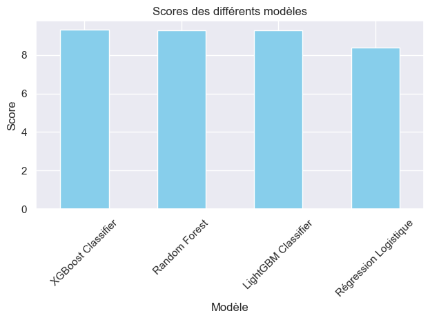

```
Le meilleur modèle est : XGBoost Classifier avec un score de 9.3
```

```python
import matplotlib.pyplot as plt

# Convertir les scores en DataFrame pandas pour une facilité de visualisation
import pandas as pd
scores_df = pd.DataFrame.from_dict(scores, orient='index', columns=['Score'])

# Tracer un diagramme à barres des scores
plt.figure(figsize=(10, 6))
scores_df.sort_values(by='Score', ascending=False).plot(kind='bar', color='skyblue', legend=None)
plt.title('Scores des différents modèles')
plt.xlabel('Modèle')
plt.ylabel('Score')
plt.xticks(rotation=45)
plt.tight_layout()
plt.show()

# Affichage du modèle gagnant
print(f"Le meilleur modèle est : {best_model} avec un score de {scores[best_model]}")
```

### Comparaison des performances des modèles de classification

Les trois premiers modèles (Random Forest, LightGBM et XGBoost) présentent des performances similaires avec une précision, un rappel et un F1-score élevés pour les deux classes. Leur exactitude est également similaire à 0.948.

Le quatrième modèle (Régression Logistique) montre des performances légèrement inférieures avec une précision, un rappel et un F1-score plus bas pour la classe 0.1. Son exactitude est de 0.885, inférieure aux autres modèles.

Les modèles Random Forest, LightGBM et XGBoost semblent mieux généraliser et détecter les deux classes de manière plus équilibrée que la Régression Logistique.

**Analyse comparative**

Random Forest présente des performances globalement bonnes avec un équilibre entre la précision et le rappel pour les deux classes.

## 6-mise en production

il faut : Documentation claire : Documentez chaque étape du processus, du prétraitement des données à l'évaluation des modèles, en passant par le déploiement. Cela facilitera la compréhension et la maintenance du système.

Tests rigoureux : Effectuez des tests exhaustifs pour vérifier le bon fonctionnement du modèle dans différents scénarios et conditions. Assurez-vous que le modèle se comporte comme prévu et qu'il répond aux spécifications.

Gestion des versions : Utilisez un système de contrôle de version comme Git pour gérer les différentes versions du code, des données et des modèles. Cela facilitera le suivi des modifications et le retour en arrière en cas de besoin.

Sécurité des données : Assurez-vous que les données utilisées par le modèle sont sécurisées et protégées contre les accès non autorisés. Mettez en place des mesures de sécurité telles que le chiffrement des données et le contrôle d'accès.

Surveillance continue : Mettez en place un système de surveillance continue pour suivre les performances du modèle en production. Surveillez les métriques de performance, détectez les dégradations de performance et prenez des mesures correctives si nécessaire.

Évolutivité : Conçoit le système pour être évolutif afin de pouvoir gérer une augmentation de la charge et de la complexité. Assurez-vous que le système peut s'adapter aux changements dans les données et les exigences commerciales.

Maintenance proactive : Planifiez régulièrement des sessions de maintenance pour mettre à jour le modèle, réévaluer les performances et apporter des améliorations. Assurez-vous que le modèle reste pertinent et efficace dans un environnement en évolution

Mise en production opérationel : Il s'agit de code Python. Chaque URL doit être transformée en vecteur numérique (21 features).

Le modèle entraîné doit être enregistré sous forme de fichier "pickle" (.pkl), qui est comme un exécutable que l'on appelle avec la librairie Joblib.

Drift : Voir avec le manager la possibilité d'avoir les données labellisées et dans quelle période. Cela nous permet de comparer la distribution des données label 0 et label 1.

Surveillance : Créer un script Python qui compare les prédictions du modèle avec les données labellisées et fixer un seuil d'accuracy pour le réentraînement.

## 7-Pour aller plus loin (perspectives)

## Exploration des Possibilités d'Amélioration de la Classification Phishing vs Non-Phishing:

## Vers une Approche Hybride Associant Modèles Traditionnels et Transformers

Pour des tâches de classification relativement simples telles que la distinction entre phishing et non-phishing, l'utilisation d'algorithmes traditionnels comme Random Forest et Régression Logistique peut être adéquate, surtout en fonction de la taille et de la complexité des données disponibles. Cependant, avec l'ajout de données supplémentaires telles que des e-mails ou d'autres types de données textuelles, nous pourrions envisager des approches plus avancées, y compris l'utilisation de modèles transformers.

L'exploitation de transformers pourrait permettre une meilleure capture des nuances et des contextes dans les données textuelles associées aux URL, ce qui pourrait améliorer les performances de classification. Une approche possible serait de pré-entraîner un modèle transformer sur un grand corpus de données textuelles liées au phishing, puis de l'ajuster finement sur notre ensemble de données spécifique.

Ensuite, nous pourrions combiner les caractéristiques extraites par le modèle transformer avec celles obtenues à partir d'algorithmes traditionnels tels que Random Forest. Cette approche hybride pourrait exploiter le meilleur des deux mondes, en combinant la capacité des transformers à comprendre le langage naturel avec la robustesse et l'interprétabilité des modèles traditionnels.

En conclusion, bien que les algorithmes traditionnels puissent être suffisants pour la classification actuelle, l'intégration de modèles transformers pourrait constituer une avenue prometteuse pour améliorer les performances à mesure que les données évoluent et deviennent plus complexes. Ce domaine offre de nombreuses opportunités de recherche et de développement pour tirer le meilleur parti des avancées dans le domaine de l'apprentissage automatique et du traitement du langage naturel.

Akram Toumani